### Relation Between Citations and Downloads for Articles in PLOS

### Introduction:

This study will focus on two variables that will be aggregated from the observed data in the spreadsheet: Citation Count and Downloads. The research question to be addressed in this study is: use the PLOS ALM (Public Library of Science, Article Level Metrics) dataset to determine if there is a correlation between citation counts (obtained from Crossref, PubMed Central, and Scopus platforms) categorized into (NONE, LOW, MEDIUM, HIGH) and total number of downloads (PLOS and PubMedCentral downloads combined).

My interest in this study is based on an effort to find ways to increase usage of published works. If a correlation can be determined, this may inform authors in the importance of submitting their research papers into prestegeous journals that have a high impact factor to ensure citations are received. This could lead to higher use of their published works. Additionally, further research may show a correlation between open source content and increased usage. This could then inform researchers to make their research more easily accessible in order to receive higher usage, which may then lead to more citations to their work.

### Data:

Citation: Public Library of Science, Article Level Metrics, Cumulative summary spreadsheet of the ALM data for the entire PLOS corpus. (2014). alm_report_2014_01_14.zip [Data set]. http://article-level-metrics.plos.org/plos-alm-data/

The cases represent data for a specific article published in the PLOS journals. Each article is identified by a DOI (Digital Object Identifier) which uniquely identifies the unit, along with the article title and publication date. Data collected for each case represents a wide range of usage across a number of different platforms, as well as counts for the number of citations each case has received.

Citation count: the maximum of the counts obtained from the “crossref”, “pubmed”, and “scopus” variables. Since the platforms providing citation counts may differ in their citation capture rules, we use a maximum value from the following sources: CrossRef, PubMed Central, and Scopus. The counts will be categorized into the values NONE (1), LOW (2), MEDIUM (3), HIGH (4) based on the following criteria:

The citation count data are categorical (ordinal).

Downloads: the sum of the “counter” and “pmc” variables. This provides a total count of usage from the PLOS and PubMed Central platforms. Total usage is based on html views, PDF downloads, and XML retrievals.

The downloads data are numerical (continuous).

The population of interest is all published articles in the scientific disciplines. The findings of this study cannot be generalized to that population as the study is performed using observations of citation counts and usage patterns for articles published only within the PLOS journal set. The findings of this study are only applicable to the set of articles published in the PLOS journals. Sources of bias might include differences in usage patterns for articles published in the open access domain versus articles published in proprietary closed journals such as Science and Nature.

Other sources of bias might include the usage patterns for specific disciplines. For example, the usage patterns of medical articles versus articles in a discipline such as computer science will likely differ. The date of publication of the article may also provide some bias, since articles more than 3 years old tend to be more highly cited than articles less than 3 years old.

### Exploratory data analysis:

Create a vector of publication years from the publication_date variable and plot:

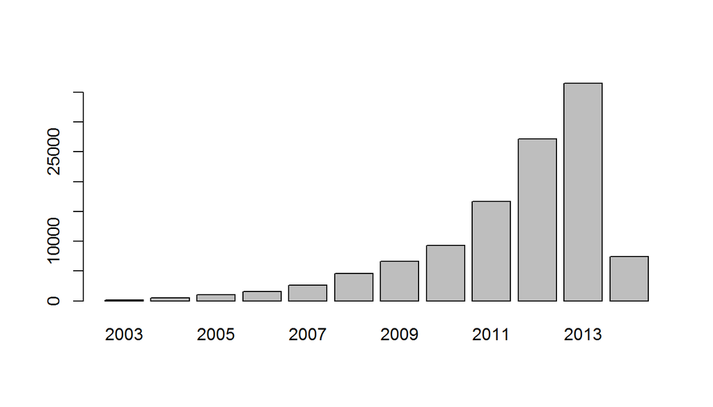

```r
pub_year <- substr(alm_report_2014.03.10$publication_date, 1, 4)
barplot(table(pub_year))
```

The barplot shows an increasing trend in number of journal articles per year. This phenomena is well known and has been documented in the literature.

Create a cite_count vector by using the maximum of the 3 citation count variables then output summary statistics:

```r
cite_count <- pmax(alm_report_2014.03.10$crossref, alm_report_2014.03.10$scopus, alm_report_2014.03.10$pubmed)
summary(cite_count)
```

```
##     Min.  1st Qu.   Median     Mean  3rd Qu.     Max.
##    0.000    0.000    2.000    8.476    8.000 1739.000
```

The summary statistics for the citation counts provides some help in determining the thresholds to apply during categorization.

Create a boxplot without outliers, to show general distribution of the citation counts:

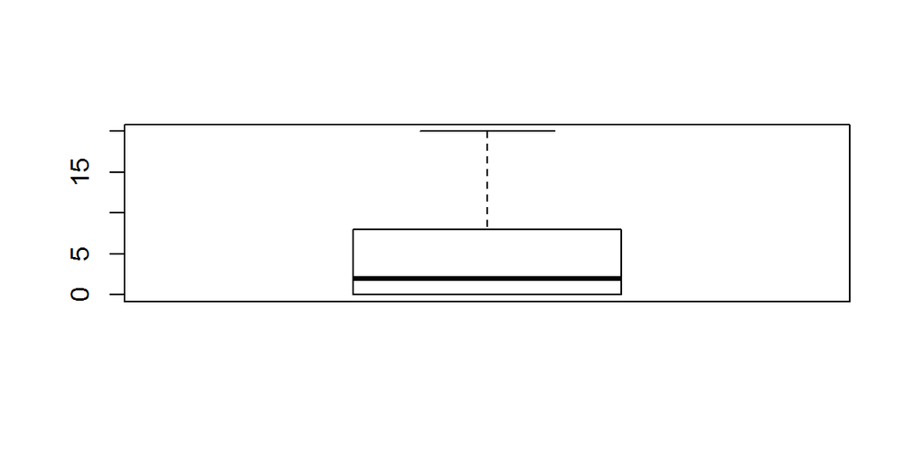

```r
boxplot(cite_count, outline=FALSE)
```

Categorize the citation count data into bins as discussed above:

```r
intervals<-c(0, 1, 10, 100, 10000)
cat_cites<-findInterval(cite_count, intervals)
```

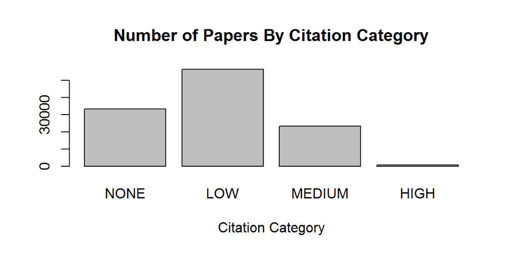

```r
maint<-c("Number of Papers By Citation Category")
xlabel<- c("Citation Category")
names<- c("NONE", "LOW", "MEDIUM", "HIGH")
barplot(main=maint, xlab=xlabel, names.arg=names, table(cat_cites))
```

Create a total_download vector by summing the 2 download count variables:

```r
total_download <- alm_report_2014.03.10$counter + alm_report_2014.03.10$pmc
```

Produce summary statistics for the total download data:

```r
summary(total_download)
```

```
##    Min. 1st Qu.  Median    Mean 3rd Qu.    Max.
##       0    1008    1955    3145    3603  972100
```

The summary statistcs show that the average number of downloads for a paper is roughly 3000. There are some outliers with a very high download count (max of 972000). Papers with a very high downlod count might indicate that some automated process was used to repeatedly download the paper in an effort to drive up the count (so called gamimg of the usage data).

The boxplot below has the outliers removed for clarity.

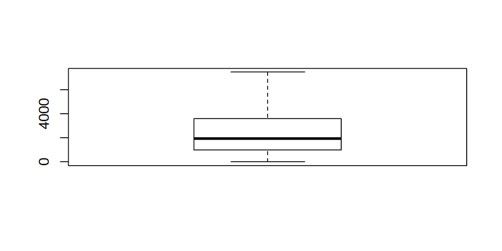

```r
boxplot(total_download, outline=FALSE)
```

### Inference:

Investigate relationship between citation category and total downloads.

Produce summary statistics for total downloads subsetted by citation category:

```r
by(total_download, cat_cites, summary)
```

```
## cat_cites: 1
##    Min. 1st Qu.  Median    Mean 3rd Qu.    Max.
##       0     322     709    1051    1204  195500
## --------------------------------------------------------
## cat_cites: 2
##    Min. 1st Qu.  Median    Mean 3rd Qu.    Max.
##       0    1384    2021    2668    2971  310800
## --------------------------------------------------------
## cat_cites: 3
##    Min. 1st Qu.  Median    Mean 3rd Qu.    Max.
##     109    3539    4960    6456    7299  226700
## --------------------------------------------------------
## cat_cites: 4
##    Min. 1st Qu.  Median    Mean 3rd Qu.    Max.
##    3627   11820   16170   22810   23970  972100
```

Create side-by-side boxplots for the downloads by citation category:

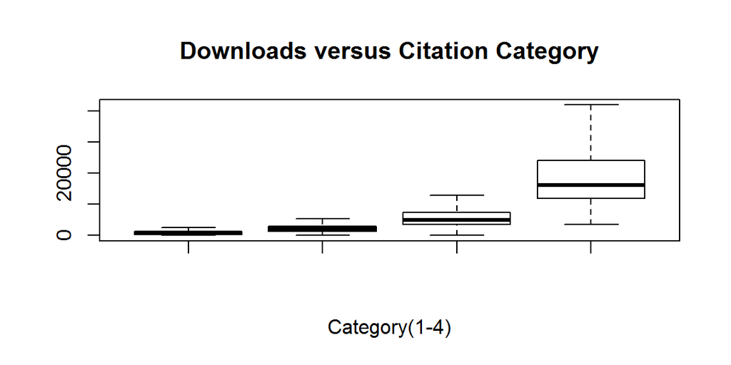

```r
boxplot(total_download[cat_cites == 1], total_download[cat_cites == 2], total_download[cat_cites == 3], total_download[cat_cites == 4], outline=FALSE, main="Downloads versus Citation Category", xlab="Category(1-4)")
```

Analysis of Variance (ANOVA)

This study will perform a hypothesis test across the citation categories to determine whether there is a statistically significant difference in the means.

H0: The means across all of the citation categories are equal. HA: At least one of the means is different.

Conditions for inference: 1) Observations are independent within and across the categories. It is assumed that the usage for each individual article is indepenent from another. This seems reasonable. Also, the sampling (114093 cases) is less than 10% of the entire journal article population. 2) The data within each group is nearly normal. 3) The variability across the citation categories is about equal.

Load the inference function into R and run the test:

```r
source("http://bit.ly/dasi_inference")
inference(y=total_download, x=as.factor(cat_cites), est="mean", type="ht", alternative="greater", method="theoretical", inf_plot=FALSE, eda_plot=FALSE, sum_stats=FALSE)
```

```
## Response variable: numerical, Explanatory variable: categorical
## ANOVA
## H_0: All means are equal.
## H_A: At least one mean is different.
## Analysis of Variance Table
##
## Response: y
##               Df     Sum Sq    Mean Sq F value    Pr(>F)
## x              3 7.8820e+11 2.6273e+11    8332 < 2.2e-16
## Residuals 114089 3.5976e+12 3.1533e+07
##
## Pairwise tests: t tests with pooled SD
##   1  2  3
## 2 0 NA NA
## 3 0  0 NA
## 4 0  0  0
```

### Conclusion:

The p-value resulting from the ANOVA test is extremely small, therefore we reject H0 (all means are equal) in favor of HA (at least one mean is different).

Therefore, researchers who want to recieve citations to their work should look to publish their works in journals that have high usage. Additionally, alternative ways to drive up usage, such as use of social media to promote publised works should also be considered. Researchers who want to promote high use of their published works should look to publish in high impact journals that recieve a higher percentage of citations.

### Appendix:

Sample data:

```r
head(alm_report_2014.03.10)
```

```
##                            doi publication_date
## 1 10.1371/journal.pcbi.0010005       2005-06-24
## 2 10.1371/journal.pcbi.0010011       2005-06-24
## 3 10.1371/journal.pcbi.0010030       2005-08-26
## 4 10.1371/journal.pcbi.0010033       2005-08-26
## 5 10.1371/journal.pcbi.0010051       2005-10-28
## 6 10.1371/journal.pcbi.0010052       2005-11-25
##                                                                           title
## 1                                       An Open Forum for Computational Biology
## 2 A Phenomenological Theory of Spatially Structured Local Synaptic Connectivity
## 3   Molecular Origin of Polyglutamine Aggregation in Neurodegenerative Diseases
## 4                                                   ISMB 2005 Conference Report
## 5                           The ISCB: Growing and Evolving in Step with Science
## 6                        Bioinformatics EducationâPerspectives and Challenges
##   citeulike mendeley crossref datacite pmceurope pmceuropedata pubmed
```

[output cut: 41 more lines]

```r
head(cat_cites)
```

```
## [1] 2 2 3 1 2 3
```

```r
head(total_download)
```

```
## [1] 4389 4738 8252 2785 1694 7754
```